# Introduction to Neural Networks: Bank Churn prediction

## Problem Statement

### Context

Businesses like banks which provide service have to worry about problem of 'Customer Churn' i.e. customers leaving and joining another service provider. It is important to understand which aspects of the service influence a customer's decision in this regard. Management can concentrate efforts on improvement of service, keeping in mind these priorities.

### Objective

You as a Data scientist with the bank need to build a neural network based classifier that can determine whether a customer will leave the bank or not in the next 6 months.

### Data Dictionary:

- CustomerId: Unique ID which is assigned to each customer
- Surname: Last name of the customer
- CreditScore: It defines the credit history of the customer.
- Geography: A customer’s location
- Gender: It defines the Gender of the customer
- Age: Age of the customer
- Tenure: Number of years for which the customer has been with the bank
- NumOfProducts: refers to the number of products that a customer has purchased through the bank.
- Balance: Account balance
- HasCrCard: It is a categorical variable which decides whether the customer has credit card or not.
- EstimatedSalary: Estimated salary
- isActiveMember: Is is a categorical variable which decides whether the customer is active member of the bank or not ( Active member in the sense, using bank products regularly, making transactions etc )
- Exited : whether or not the customer left the bank within six month. It can take two values **0=No ( Customer did not leave the bank )** 1=Yes ( Customer left the bank )

## Importing necessary libraries

```python
# Libraries to help with reading and manipulating data
import pandas as pd
import numpy as np

# Library to split data
from sklearn.model_selection import train_test_split

# Library to encode the variables
from sklearn import preprocessing

# To plot confusion matrix
from sklearn.metrics import confusion_matrix

# libaries to help with data visualization
import matplotlib.pyplot as plt
import seaborn as sns

# library to import to standardize the data
from sklearn.preprocessing import StandardScaler

#To import different metrics
from sklearn import metrics
from tensorflow.keras import backend


# importing GridSearch CV
from sklearn.model_selection import GridSearchCV

# importing roc_curve to plot
from sklearn.metrics import roc_curve
from matplotlib import pyplot

# importing SMOTE
from imblearn.over_sampling import SMOTE

# importing metrics
from sklearn import metrics
import random


# importing neural network libraries

import tensorflow as tf
from tensorflow import keras
from tensorflow.keras import Sequential
from tensorflow.keras.layers import Flatten, Dense, Dropout
from tensorflow.keras.callbacks import EarlyStopping
from tensorflow.keras.wrappers.scikit_learn import KerasClassifier


# Importing optimizers
from tensorflow.keras.optimizers import Adam
from tensorflow.keras.optimizers import RMSprop

#Importing classback API
from keras import callbacks

# libraries for data processing and train-test data spliting

from sklearn.preprocessing import LabelEncoder
from sklearn.preprocessing import StandardScaler
from sklearn.model_selection import train_test_split

# libraries for metrics
from sklearn.metrics import confusion_matrix, accuracy_score
from mlxtend.plotting import plot_confusion_matrix


# Library to avoid the warnings
import warnings
warnings.filterwarnings("ignore")
```

## Loading the dataset

```python
ds = pd.read_csv("bank-1.csv")
ds.head()
```

|  | RowNumber | CustomerId | Surname | CreditScore | Geography | Gender | Age | Tenure | Balance | NumOfProducts | HasCrCard | IsActiveMember | EstimatedSalary | Exited |
| --- | --- | --- | --- | --- | --- | --- | --- | --- | --- | --- | --- | --- | --- | --- |
| 0 | 1 | 15634602 | Hargrave | 619 | France | Female | 42 | 2 | 0.00 | 1 | 1 | 1 | 101348.88 | 1 |
| 1 | 2 | 15647311 | Hill | 608 | Spain | Female | 41 | 1 | 83807.86 | 1 | 0 | 1 | 112542.58 | 0 |
| 2 | 3 | 15619304 | Onio | 502 | France | Female | 42 | 8 | 159660.80 | 3 | 1 | 0 | 113931.57 | 1 |
| 3 | 4 | 15701354 | Boni | 699 | France | Female | 39 | 1 | 0.00 | 2 | 0 | 0 | 93826.63 | 0 |
| 4 | 5 | 15737888 | Mitchell | 850 | Spain | Female | 43 | 2 | 125510.82 | 1 | 1 | 1 | 79084.10 | 0 |

```python
ds.tail(5)
```

|  | RowNumber | CustomerId | Surname | CreditScore | Geography | Gender | Age | Tenure | Balance | NumOfProducts | HasCrCard | IsActiveMember | EstimatedSalary | Exited |
| --- | --- | --- | --- | --- | --- | --- | --- | --- | --- | --- | --- | --- | --- | --- |
| 9995 | 9996 | 15606229 | Obijiaku | 771 | France | Male | 39 | 5 | 0.00 | 2 | 1 | 0 | 96270.64 | 0 |
| 9996 | 9997 | 15569892 | Johnstone | 516 | France | Male | 35 | 10 | 57369.61 | 1 | 1 | 1 | 101699.77 | 0 |
| 9997 | 9998 | 15584532 | Liu | 709 | France | Female | 36 | 7 | 0.00 | 1 | 0 | 1 | 42085.58 | 1 |
| 9998 | 9999 | 15682355 | Sabbatini | 772 | Germany | Male | 42 | 3 | 75075.31 | 2 | 1 | 0 | 92888.52 | 1 |
| 9999 | 10000 | 15628319 | Walker | 792 | France | Female | 28 | 4 | 130142.79 | 1 | 1 | 0 | 38190.78 | 0 |

## Data Overview

```python
ds.shape
```

```
(10000, 14)
```

```python
ds.info()
```

```
<class 'pandas.core.frame.DataFrame'>
RangeIndex: 10000 entries, 0 to 9999
Data columns (total 14 columns):
 #   Column           Non-Null Count  Dtype
---  ------           --------------  -----
 0   RowNumber        10000 non-null  int64
 1   CustomerId       10000 non-null  int64
 2   Surname          10000 non-null  object
 3   CreditScore      10000 non-null  int64
 4   Geography        10000 non-null  object
 5   Gender           10000 non-null  object
 6   Age              10000 non-null  int64
 7   Tenure           10000 non-null  int64
 8   Balance          10000 non-null  float64
 9   NumOfProducts    10000 non-null  int64
 10  HasCrCard        10000 non-null  int64
 11  IsActiveMember   10000 non-null  int64
 12  EstimatedSalary  10000 non-null  float64
 13  Exited           10000 non-null  int64
dtypes: float64(2), int64(9), object(3)
memory usage: 1.1+ MB
```

```python
ds.isna().sum()
```

```
RowNumber          0
CustomerId         0
Surname            0
CreditScore        0
Geography          0
Gender             0
Age                0
Tenure             0
Balance            0
NumOfProducts      0
HasCrCard          0
IsActiveMember     0
EstimatedSalary    0
Exited             0
dtype: int64
```

```python
ds.columns
```

```
Index(['RowNumber', 'CustomerId', 'Surname', 'CreditScore', 'Geography',
       'Gender', 'Age', 'Tenure', 'Balance', 'NumOfProducts', 'HasCrCard',
       'IsActiveMember', 'EstimatedSalary', 'Exited'],
      dtype='object')
```

```python
rows = ds.shape[0]
cols = ds.shape[1]


print(f"There are {rows} rows and {cols} columns.") ## Complete the code to get the shape of data
```

```
There are 10000 rows and 14 columns.
```

```python
ds.describe().T
```

|  | count | mean | std | min | 25% | 50% | 75% | max |
| --- | --- | --- | --- | --- | --- | --- | --- | --- |
| RowNumber | 10000.0 | 5.000500e+03 | 2886.895680 | 1.00 | 2500.75 | 5.000500e+03 | 7.500250e+03 | 10000.00 |
| CustomerId | 10000.0 | 1.569094e+07 | 71936.186123 | 15565701.00 | 15628528.25 | 1.569074e+07 | 1.575323e+07 | 15815690.00 |
| CreditScore | 10000.0 | 6.505288e+02 | 96.653299 | 350.00 | 584.00 | 6.520000e+02 | 7.180000e+02 | 850.00 |
| Age | 10000.0 | 3.892180e+01 | 10.487806 | 18.00 | 32.00 | 3.700000e+01 | 4.400000e+01 | 92.00 |
| Tenure | 10000.0 | 5.012800e+00 | 2.892174 | 0.00 | 3.00 | 5.000000e+00 | 7.000000e+00 | 10.00 |
| Balance | 10000.0 | 7.648589e+04 | 62397.405202 | 0.00 | 0.00 | 9.719854e+04 | 1.276442e+05 | 250898.09 |
| NumOfProducts | 10000.0 | 1.530200e+00 | 0.581654 | 1.00 | 1.00 | 1.000000e+00 | 2.000000e+00 | 4.00 |
| HasCrCard | 10000.0 | 7.055000e-01 | 0.455840 | 0.00 | 0.00 | 1.000000e+00 | 1.000000e+00 | 1.00 |
| IsActiveMember | 10000.0 | 5.151000e-01 | 0.499797 | 0.00 | 0.00 | 1.000000e+00 | 1.000000e+00 | 1.00 |
| EstimatedSalary | 10000.0 | 1.000902e+05 | 57510.492818 | 11.58 | 51002.11 | 1.001939e+05 | 1.493882e+05 | 199992.48 |
| Exited | 10000.0 | 2.037000e-01 | 0.402769 | 0.00 | 0.00 | 0.000000e+00 | 0.000000e+00 | 1.00 |

#### Observations:

```python
customer_data_copy1 = ds.copy()
```

#### Unique values

```python
### NumOfProducts

customer_data_copy1["NumOfProducts"].unique()
```

```
array([1, 3, 2, 4])
```

```python
### HasCrCard

customer_data_copy1["HasCrCard"].unique()
```

```
array([1, 0])
```

```python
### IsActiveMember


customer_data_copy1["IsActiveMember"].unique()
```

```
array([1, 0])
```

```python
### Tenure

customer_data_copy1["Tenure"].unique()
```

```
array([ 2,  1,  8,  7,  4,  6,  3, 10,  5,  9,  0])
```

```python
### Exited

customer_data_copy1["Exited"].unique()
```

```
array([1, 0])
```

#### Counts for various features w.r.to. customers

```python
# Count of people with various NumOfProducts :

customer_data_copy1['NumOfProducts'].value_counts()
```

```
1    5084
2    4590
3     266
4      60
Name: NumOfProducts, dtype: int64
```

```python
# Count of people with various HasCrCard :

customer_data_copy1['HasCrCard'].value_counts()
```

```
1    7055
0    2945
Name: HasCrCard, dtype: int64
```

```python
# Count of people with IsActiveMember :

customer_data_copy1['IsActiveMember'].value_counts()
```

```
1    5151
0    4849
Name: IsActiveMember, dtype: int64
```

```python
# Count of people with various Tenure :

customer_data_copy1['Tenure'].value_counts()
```

```
2     1048
1     1035
7     1028
8     1025
5     1012
3     1009
4      989
9      984
6      967
10     490
0      413
Name: Tenure, dtype: int64
```

```python
# Count of people with various Exited status :

customer_data_copy1['Exited'].value_counts()
```

```
0    7963
1    2037
Name: Exited, dtype: int64
```

#### Observations:

**Customer Tenure** It appears that customers with tenure values of 2 and 1 are the most common, while customers with tenure values of 0 and 10 are the least common. The distribution of tenure values can provide insights into the customer base's loyalty and stability.

## Exploratory Data Analysis

### Univariate Analysis

```python
# function to plot a boxplot and a histogram along the same scale.


def histogram_boxplot(data, feature, figsize=(12, 7), kde=False, bins=None):
    """
    Boxplot and histogram combined

    data: dataframe
    feature: dataframe column
    figsize: size of figure (default (12,7))
    kde: whether to show the density curve (default False)
    bins: number of bins for histogram (default None)
    """
    f2, (ax_box2, ax_hist2) = plt.subplots(
        nrows=2,  # Number of rows of the subplot grid= 2
        sharex=True,  # x-axis will be shared among all subplots
        gridspec_kw={"height_ratios": (0.25, 0.75)},
        figsize=figsize,
    )  # creating the 2 subplots
    sns.boxplot(
        data=data, x=feature, ax=ax_box2, showmeans=True, color="violet"
    )  # boxplot will be created and a star will indicate the mean value of the column
    sns.histplot(
        data=data, x=feature, kde=kde, ax=ax_hist2, bins=bins, palette="winter"
    ) if bins else sns.histplot(
        data=data, x=feature, kde=kde, ax=ax_hist2
    )  # For histogram
    ax_hist2.axvline(
        data[feature].mean(), color="green", linestyle="--"
    )  # Add mean to the histogram
    ax_hist2.axvline(
        data[feature].median(), color="black", linestyle="-"
    )  # Add median to the histogram
```

```python
# function to create labeled barplots


def labeled_barplot(data, feature, perc=False, n=None):
    """
    Barplot with percentage at the top

    data: dataframe
    feature: dataframe column
    perc: whether to display percentages instead of count (default is False)
    n: displays the top n category levels (default is None, i.e., display all levels)
    """

    total = len(data[feature])  # length of the column
    count = data[feature].nunique()
    if n is None:
        plt.figure(figsize=(count + 1, 5))
    else:
        plt.figure(figsize=(n + 1, 5))

    plt.xticks(rotation=90, fontsize=15)
    ax = sns.countplot(
        data=data,
        x=feature,
        palette="Paired",
        order=data[feature].value_counts().index[:n].sort_values(),
    )

    for p in ax.patches:
        if perc == True:
            label = "{:.1f}%".format(
                100 * p.get_height() / total
            )  # percentage of each class of the category
        else:
            label = p.get_height()  # count of each level of the category

        x = p.get_x() + p.get_width() / 2  # width of the plot
        y = p.get_height()  # height of the plot

        ax.annotate(
            label,
            (x, y),
            ha="center",
            va="center",
            size=12,
            xytext=(0, 5),
            textcoords="offset points",
        )  # annotate the percentage

    plt.show()  # show the plot
```

#### Observations on CreditScore

- A few outliers exhibit credit scores below 400, while the majority of customers fall within the credit score range of 550 to 725. The median credit score is approximately 650.

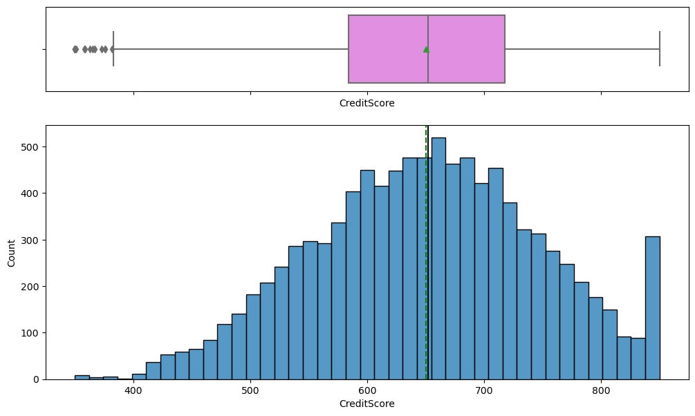

```python
histogram_boxplot(customer_data_copy1,'CreditScore')
```

#### Observations on Age

- There are a few outliers in the age range of 65 to 90, but the majority of customers are aged between 30 and 45. The median age is approximately 37.

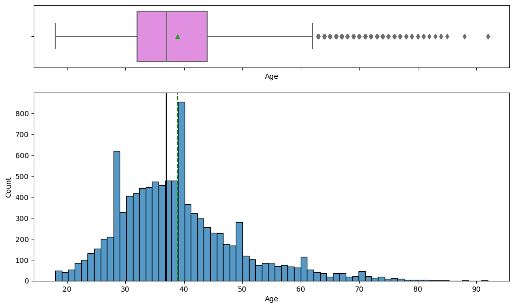

```python
histogram_boxplot(customer_data_copy1,'Age')
```

#### Observations on Balance

- There are over 3,500 customers with zero account balances. Most individuals maintain account balances between 75,000 and 175,000, but there are a few customers with balances exceeding 200,000.

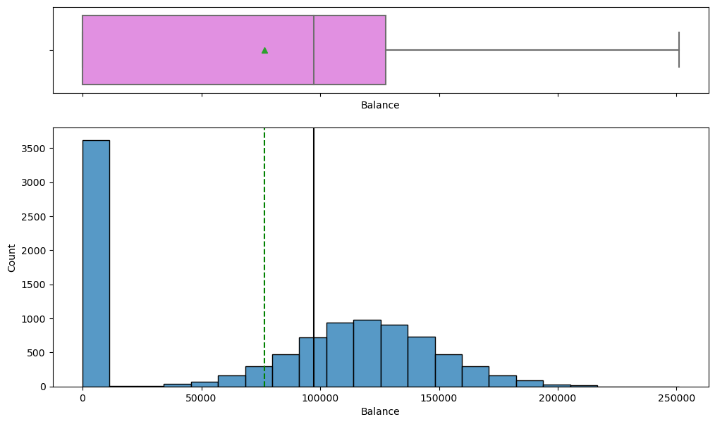

```python
histogram_boxplot(customer_data_copy1, 'Balance')
```

#### Observations on Estimated Salary

- Approximately 50% of customers have salaries that fall within the range of 50,000 to 150,000. The highest recorded salary is around 200,000, with roughly 450 customers earning at or above this level.

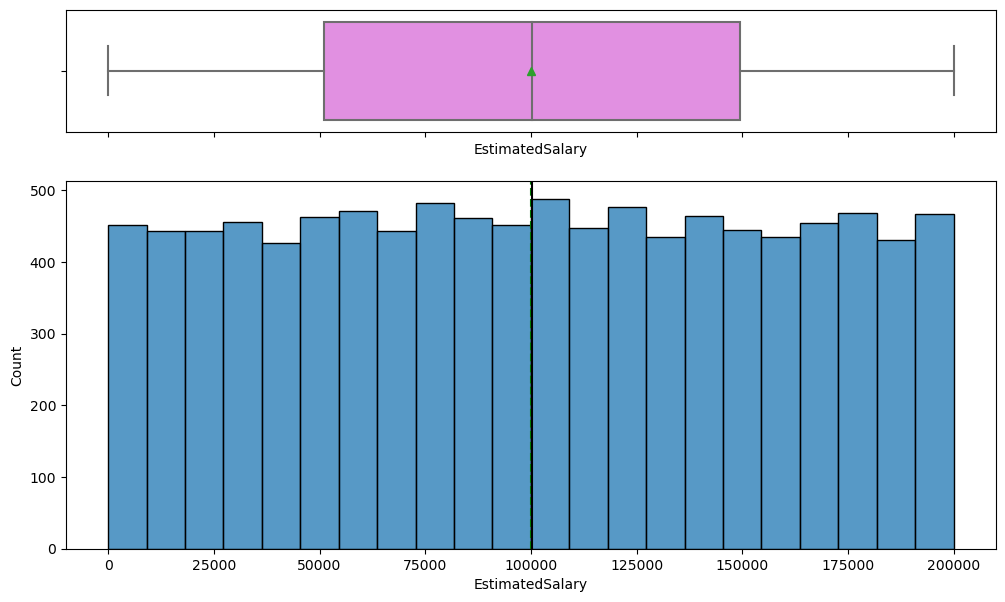

```python
histogram_boxplot(customer_data_copy1, 'EstimatedSalary')
```

#### Observations on Exited

- Approximately 79% of customers have not exited the bank, while the remaining percentage represents those who have exited.

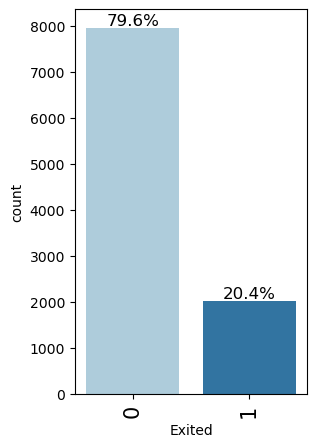

```python
labeled_barplot(customer_data_copy1, "Exited", perc=True)
```

#### Observations on Geography

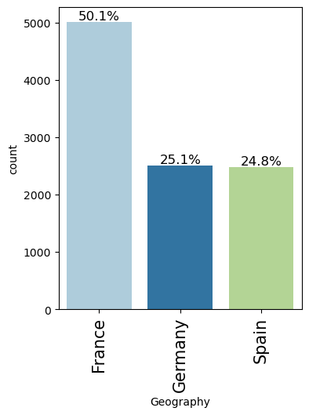

```python
labeled_barplot(customer_data_copy1, "Geography", perc=True)
```

#### Observations on Gender

- Approximately 55% of the customers are male, with the remaining portion being female.

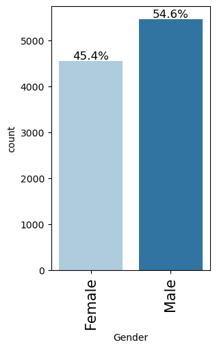

```python
labeled_barplot(customer_data_copy1, "Gender", perc=True)
```

#### Observations on Tenure

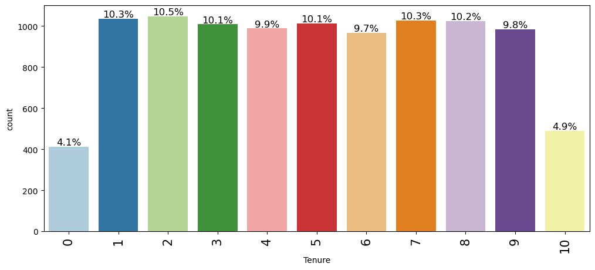

```python
labeled_barplot(customer_data_copy1, "Tenure", perc=True)
```

#### Observations on Number of Products

- Over 50% of customers have at least one product, and approximately 45% of customers possess two products. Some customers have more than two products.

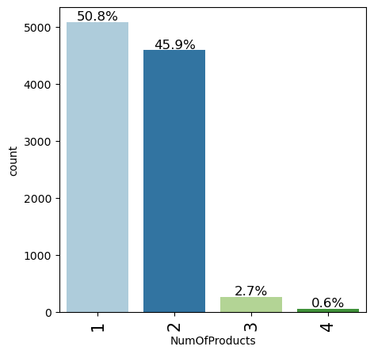

```python
labeled_barplot(customer_data_copy1, "NumOfProducts", perc=True)
```

#### Observations on Has Credit Card

- Credit cards are held by over 70% of the customers.

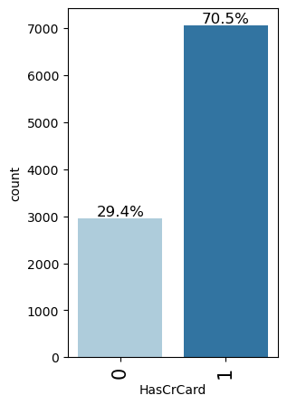

```python
labeled_barplot(customer_data_copy1, "HasCrCard", perc=True)
```

#### Observations on Is Active Member

- Over 50% of the customers are considered active members.

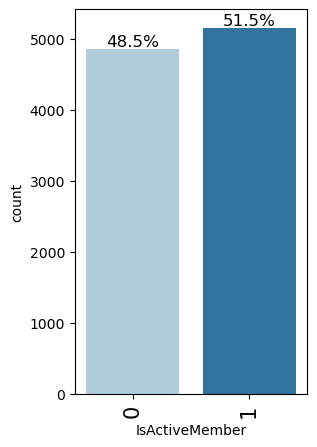

```python
labeled_barplot(customer_data_copy1, "IsActiveMember", perc=True)
```

### Bivariate Analysis

```python
# function to plot stacked bar chart


def stacked_barplot(data, predictor, target):
    """
    Print the category counts and plot a stacked bar chart

    data: dataframe
    predictor: independent variable
    target: target variable
    """
    count = data[predictor].nunique()
    sorter = data[target].value_counts().index[-1]
    tab1 = pd.crosstab(data[predictor], data[target], margins=True).sort_values(
        by=sorter, ascending=False
    )
    print(tab1)
    print("-" * 120)
    tab = pd.crosstab(data[predictor], data[target], normalize="index").sort_values(
        by=sorter, ascending=False
    )
    tab.plot(kind="bar", stacked=True, figsize=(count + 1, 5))
    plt.legend(
        loc="lower left",
        frameon=False,
    )
    plt.legend(loc="upper left", bbox_to_anchor=(1, 1))
    plt.show()
```

#### Correlation plot

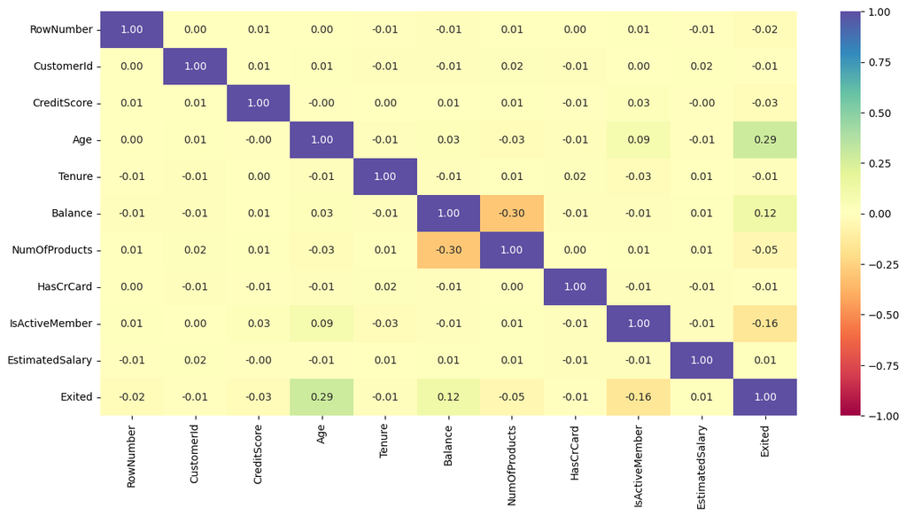

```python
plt.figure(figsize=(15, 7))
sns.heatmap(customer_data_copy1.corr(), annot=True, vmin=-1, vmax=1, fmt=".2f", cmap="Spectral")          # Complete the code to get the heatmap of the data
plt.show()
```

#### Exited Vs Geography

```
Exited        0     1    All
Geography
All        7963  2037  10000
Germany    1695   814   2509
France     4204   810   5014
Spain      2064   413   2477
------------------------------------------------------------------------------------------------------------------------
```

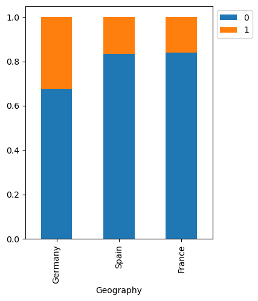

```python
stacked_barplot(customer_data_copy1, "Geography", "Exited" )
```

#### Observations:

**For All Geographies:**

- 7,963 customers did not exit (0).
- 2,037 customers did exit (1).
- There are a total of 10,000 customers in the dataset.

**For Germany:**

- In Germany, 1,695 customers did not exit (0).
- 814 customers did exit (1).
- There are a total of 2,509 customers in Germany.

**For France:**

- In France, 4,204 customers did not exit (0).
- 810 customers did exit (1).
- There are a total of 5,014 customers in France.

**For Spain:**

- In Spain, 2,064 customers did not exit (0).
- 413 customers did exit (1).
- There are a total of 2,477 customers in Spain.

#### Exited Vs Gender

```
Exited     0     1    All
Gender
All     7963  2037  10000
Female  3404  1139   4543
Male    4559   898   5457
------------------------------------------------------------------------------------------------------------------------
```

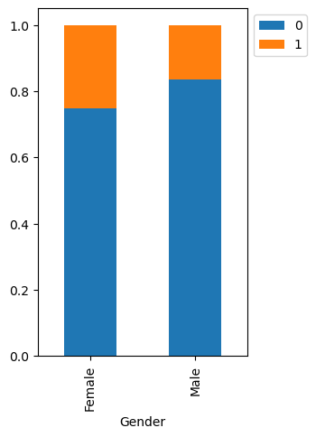

```python
stacked_barplot(customer_data_copy1, "Gender", "Exited" )
```

#### Observations

**For All Genders:**

- 7,963 customers did not exit (0).
- 2,037 customers did exit (1).
- There are a total of 10,000 customers in the dataset.

**For Female Customers:**

- 3,404 female customers did not exit (0).
- 1,139 female customers did exit (1).
- There are a total of 4,543 female customers in the dataset.

**For Male Customers:**

- 4,559 male customers did not exit (0).
- 898 male customers did exit (1).
- There are a total of 5,457 male customers in the dataset.

#### Exited Vs Has Credit Card

```
Exited        0     1    All
HasCrCard
All        7963  2037  10000
1          5631  1424   7055
0          2332   613   2945
------------------------------------------------------------------------------------------------------------------------
```

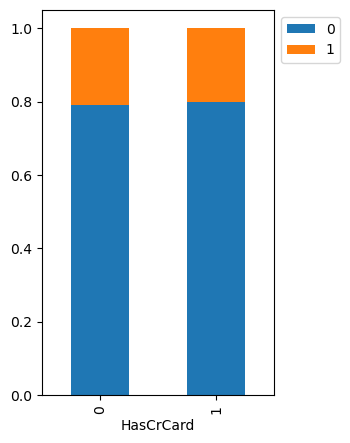

```python
stacked_barplot(customer_data_copy1, "HasCrCard", "Exited" )
```

#### Observations

**For All Customers (HasCrCard):**

**For Customers with Credit Card (HasCrCard=1):**

- 5,631 customers with credit cards did not exit (0).
- 1,424 customers with credit cards did exit (1).
- There are a total of 7,055 customers with credit cards in the dataset.

**For Customers without Credit Card (HasCrCard=0):**

- 2,332 customers without credit cards did not exit (0).
- 613 customers without credit cards did exit (1).
- There are a total of 2,945 customers without credit cards in the dataset.

```
Exited             0     1    All
IsActiveMember
All             7963  2037  10000
0               3547  1302   4849
1               4416   735   5151
------------------------------------------------------------------------------------------------------------------------
```

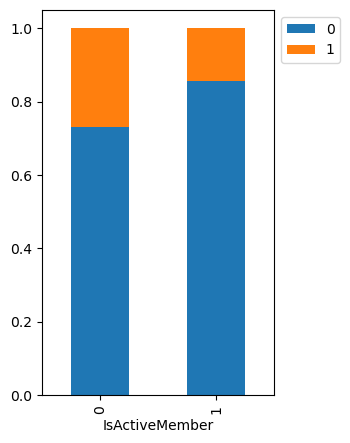

```python
stacked_barplot(customer_data_copy1, "IsActiveMember", "Exited" )
```

#### Exited Vs Credit Score

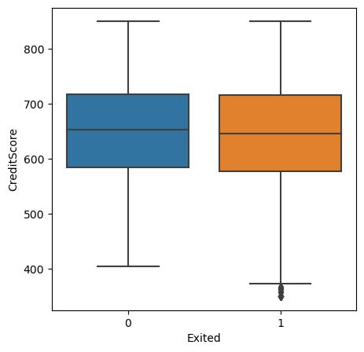

```python
plt.figure(figsize=(5,5))
sns.boxplot(y='CreditScore',x='Exited',data=customer_data_copy1)
plt.show()
```

#### Exited Vs Age

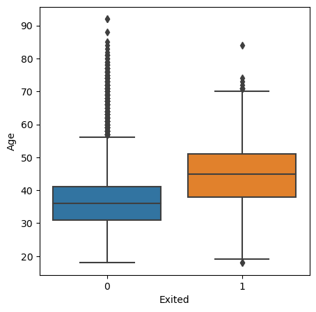

```python
plt.figure(figsize=(5,5))
sns.boxplot(y='Age',x='Exited',data=customer_data_copy1)
plt.show()
```

#### Exited Vs Tenure

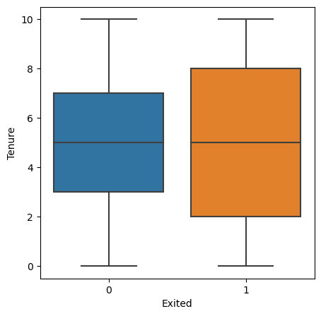

```python
plt.figure(figsize=(5,5))
sns.boxplot(y='Tenure',x='Exited',data=customer_data_copy1)
plt.show()
```

#### Exited Vs Balance

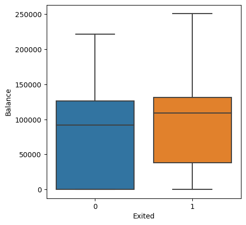

```python
plt.figure(figsize=(5,5))
sns.boxplot(y='Balance',x='Exited',data=customer_data_copy1)
plt.show()
```

#### Exited Vs Number of Products

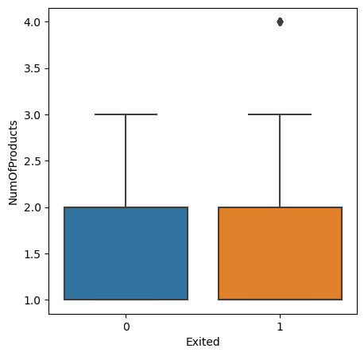

```python
plt.figure(figsize=(5,5))
sns.boxplot(y='NumOfProducts',x='Exited',data=customer_data_copy1)
plt.show()
```

#### Exited Vs Estimated Salary

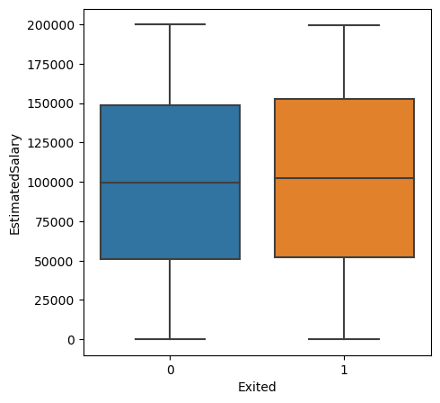

```python
plt.figure(figsize=(5,5))
sns.boxplot(y='EstimatedSalary',x='Exited',data=customer_data_copy1)
plt.show()
```

## Data Preprocessing

### Data Preparation for Modeling

- We want to predict the churn.
- Before we proceed to build a model, We'll split the data into train and test to be able to evaluate the model that we build on the train data
- We'll have to encode categorical features.
- We will build a model using the train data and then check it's performance

```python
customer_data_copy2 = customer_data_copy1.copy()


# list of continuous and categorical variables/features

continuous_vars = ['CreditScore',  'Age', 'Tenure', 'Balance','NumOfProducts', 'EstimatedSalary']
categorical_vars = ['HasCrCard', 'IsActiveMember','Geography', 'Gender']
```

```python
## Obtain the independent features into variable X
X = customer_data_copy2.drop(['RowNumber','CustomerId','Exited', 'Surname'],axis=1)

## Obtain the dependent features into variable y
y = customer_data_copy2[['Exited']]
```

```python
### REPLACE WITH ONE HOT ENCODING!
# one-hot encoding of categorical variables

labelEncoder = LabelEncoder()

X['Geography'] = labelEncoder.fit_transform(X['Geography'])
X['Gender'] = labelEncoder.fit_transform(X['Gender'])

X.head()
```

|  | CreditScore | Geography | Gender | Age | Tenure | Balance | NumOfProducts | HasCrCard | IsActiveMember | EstimatedSalary |
| --- | --- | --- | --- | --- | --- | --- | --- | --- | --- | --- |
| 0 | 619 | 0 | 0 | 42 | 2 | 0.00 | 1 | 1 | 1 | 101348.88 |
| 1 | 608 | 2 | 0 | 41 | 1 | 83807.86 | 1 | 0 | 1 | 112542.58 |
| 2 | 502 | 0 | 0 | 42 | 8 | 159660.80 | 3 | 1 | 0 | 113931.57 |
| 3 | 699 | 0 | 0 | 39 | 1 | 0.00 | 2 | 0 | 0 | 93826.63 |
| 4 | 850 | 2 | 0 | 43 | 2 | 125510.82 | 1 | 1 | 1 | 79084.10 |

```python
y.head()
```

|  | Exited |
| --- | --- |
| 0 | 1 |
| 1 | 0 |
| 2 | 1 |
| 3 | 0 |
| 4 | 0 |

```python
# Splitting the dataset into the Training and Testing set. (80 % - 20 % split)


## Split the X and y and obtain test set
X_large, X_test, y_large, y_test = train_test_split(X,y, test_size = 0.2, random_state = 42,stratify=y,shuffle = True)
```

```python
print('X_large : ', X_large.shape)
print('y_large : ', y_large.shape)
print('X_test :  ', X_test.shape)
print('y_test :  ', y_test.shape)
```

```
X_large :  (8000, 10)
y_large :  (8000, 1)
X_test :   (2000, 10)
y_test :   (2000, 1)
```

```python
## Split X_large and y_large to obtain train and validation sets  (80 % - 20 % split)
X_train, X_val, y_train, y_val = train_test_split(X_large,y_large, test_size = 0.2, random_state = 42,stratify=y_large, shuffle = True)
```

```python
# Checking the shape
print('X_train : ', X_train.shape)
print('y_train : ', y_train.shape)
print('X_val :   ', X_val.shape)
print('y_val :   ', y_val.shape)
print('X_test :  ', X_test.shape)
print('y_test :  ', y_test.shape)
```

```
X_train :  (6400, 10)
y_train :  (6400, 1)
X_val :    (1600, 10)
y_val :    (1600, 1)
X_test :   (2000, 10)
y_test :   (2000, 1)
```

```python
## Complete the below code to scale the data using standardscaler
sc=StandardScaler()
temp = sc.fit(X_train[["CreditScore","Age","Tenure","Balance","EstimatedSalary"]])
X_train[["CreditScore","Age","Tenure","Balance","EstimatedSalary"]] = temp.transform(X_train[["CreditScore","Age","Tenure","Balance","EstimatedSalary"]])
X_test[["CreditScore","Age","Tenure","Balance","EstimatedSalary"]] = temp.transform(X_test[["CreditScore","Age","Tenure","Balance","EstimatedSalary"]])
X_val[["CreditScore","Age","Tenure","Balance","EstimatedSalary"]] = temp.transform(X_val[["CreditScore","Age","Tenure","Balance","EstimatedSalary"]])
```

#### Observations:

The provided observations indicate the dimensions of the datasets for training, validation, and testing for a machine learning or neural network model:

- X_train: The training dataset consists of 6,400 samples with 10 features each.
- y_train: The corresponding target values for the training dataset, typically used for supervised learning, contain 6,400 labels (one per sample).
- X_val: The validation dataset includes 1,600 samples with 10 features each. This dataset is typically used for tuning model hyperparameters and assessing its performance.
- y_val: The associated target values for the validation dataset contain 1,600 labels.
- X_test: The test dataset comprises 2,000 samples with 10 features each, which are used to evaluate the model's generalization to unseen data.
- y_test: The corresponding target values for the test dataset consist of 2,000 labels.

## Model Building

### Model Evaluation Criterion

**Model can make wrong predictions as:**

- Predicting a customer is exiting and the customer is not exiting
- Predicting a customer is not exiting and customer is exiting

**Which case is more important?**

- Predicting that customer is not exiting but he/she is exiting. It might cause loss to the banks because due to wrong identification bank will not be able to take any initiative for those sensitive customers.

**How to reduce this loss i.e need to reduce False Negative?**

- Bank would want `Recall` to be maximized, greater the Recall higher the chances of minimizing false Negative. Hence, the focus should be on increasing Recall or minimizing the false Negative or in other words identifying the True Positive(i.e. Class 1) so that the bank can retain their customers.

**Create a function for plotting the confusion matrix**

```python
def make_confusion_matrix(cf,
                          group_names=None,
                          categories='auto',
                          count=True,
                          percent=True,
                          cbar=True,
                          xyticks=True,
                          xyplotlabels=True,
                          sum_stats=True,
                          figsize=None,
                          cmap='Blues',
                          title=None):
    '''
    This function will make a pretty plot of an sklearn Confusion Matrix cm using a Seaborn heatmap visualization.
    Arguments
    '''
    stats_text = ""

    # CODE TO GENERATE TEXT INSIDE EACH SQUARE
    blanks = ['' for i in range(cf.size)]

    if group_names and len(group_names)==cf.size:
        group_labels = ["{}\n".format(value) for value in group_names]
    else:
        group_labels = blanks

    if count:
        group_counts = ["{0:0.0f}\n".format(value) for value in cf.flatten()]
    else:
        group_counts = blanks

    if percent:
        group_percentages = ["{0:.2%}".format(value) for value in cf.flatten()/np.sum(cf)]
    else:
        group_percentages = blanks

    box_labels = [f"{v1}{v2}{v3}".strip() for v1, v2, v3 in zip(group_labels,group_counts,group_percentages)]
    box_labels = np.asarray(box_labels).reshape(cf.shape[0],cf.shape[1])


    # CODE TO GENERATE SUMMARY STATISTICS & TEXT FOR SUMMARY STATS
    if sum_stats:
        #Accuracy is sum of diagonal divided by total observations
        accuracy  = np.trace(cf) / float(np.sum(cf))

        #if it is a binary confusion matrix, show some more stats
        if len(cf)==2:
            #Metrics for Binary Confusion Matrices
            precision = cf[1,1] / sum(cf[:,1])
            recall    = cf[1,1] / sum(cf[1,:])
            f1_score  = 2*precision*recall / (precision + recall)
            stats_text = "\n\nAccuracy={:0.3f}\nPrecision={:0.3f}\nRecall={:0.3f}\nF1 Score={:0.3f}".format(
                accuracy,precision,recall,f1_score)
        else:
            stats_text = "\n\nAccuracy={:0.3f}".format(accuracy)
    else:
        stats_text = ""


    # SET FIGURE PARAMETERS ACCORDING TO OTHER ARGUMENTS
    if figsize==None:
        #Get default figure size if not set
        figsize = plt.rcParams.get('figure.figsize')

    if xyticks==False:
        #Do not show categories if xyticks is False
        categories=False


    # MAKE THE HEATMAP VISUALIZATION
    plt.figure(figsize=figsize)
    sns.heatmap(cf,annot=box_labels,fmt="",cmap=cmap,cbar=cbar,xticklabels=categories,yticklabels=categories)

    if xyplotlabels:
        plt.ylabel('True label')
        plt.xlabel('Predicted label' + stats_text)
    else:
        plt.xlabel(stats_text)

    if title:
        plt.title(title)

    return stats_text
```

### 1. Model Building: Neural Network

```python
#customer_data_copy2

backend.clear_session()
#Fixing the seed for random number generators so that we can ensure we receive the same output everytime
np.random.seed(42)
random.seed(42)
tf.random.set_seed(42)
```

```python
# Initializing the ANN
model1 = Sequential()
model1.add(Dense(64, activation = 'relu', input_dim = X.shape[1]))

# Complete the code to add the 1st hidden layer with 32 neurons
model1.add(Dense(32, activation='relu'))

# Add the output layer with one node and sigmoid activation function
model1.add(Dense(1, activation='sigmoid'))
```

```python
model1.summary()
```

```
Model: "sequential"
_________________________________________________________________
 Layer (type)                Output Shape              Param #
=================================================================
 dense (Dense)               (None, 64)                704

 dense_1 (Dense)             (None, 32)                2080

 dense_2 (Dense)             (None, 1)                 33

=================================================================
Total params: 2,817
Trainable params: 2,817
Non-trainable params: 0
_________________________________________________________________
```

```python
## Complete the code to Compile the model with Adam optimizer
## and binary cross entropy as loss with accuracy as metrics

model1.compile(optimizer = 'adam',
                 loss = 'binary_crossentropy',
                 metrics=['accuracy'])
```

```python
## Complete the code to obtain the summary of the model
model1.summary()
```

```
Model: "sequential"
_________________________________________________________________
 Layer (type)                Output Shape              Param #
=================================================================
 dense (Dense)               (None, 64)                704

 dense_1 (Dense)             (None, 32)                2080

 dense_2 (Dense)             (None, 1)                 33

=================================================================
Total params: 2,817
Trainable params: 2,817
Non-trainable params: 0
_________________________________________________________________
```

```python
X_train.head()
```

|  | CreditScore | Geography | Gender | Age | Tenure | Balance | NumOfProducts | HasCrCard | IsActiveMember | EstimatedSalary |
| --- | --- | --- | --- | --- | --- | --- | --- | --- | --- | --- |
| 3006 | 0.988678 | 0 | 0 | 0.572685 | -1.384980 | 0.610704 | 1 | 1 | 0 | 1.566070 |
| 5735 | -0.683985 | 2 | 0 | 0.477619 | -0.355056 | -1.237347 | 2 | 0 | 1 | 0.036348 |
| 5652 | 0.410474 | 0 | 0 | -0.948376 | 1.361485 | -1.237347 | 2 | 0 | 0 | 1.745403 |
| 26 | 1.081604 | 1 | 1 | -0.282911 | -1.041672 | 0.962063 | 1 | 1 | 1 | 1.228816 |
| 3596 | -0.085130 | 0 | 1 | -0.282911 | -1.728288 | 1.144427 | 1 | 0 | 0 | -0.764748 |

```python
y_train
```

|  | Exited |
| --- | --- |
| 3006 | 1 |
| 5735 | 0 |
| 5652 | 0 |
| 26 | 0 |
| 3596 | 0 |
| ... | ... |
| 3239 | 0 |
| 413 | 1 |
| 5787 | 0 |
| 860 | 1 |
| 1558 | 0 |

6400 rows × 1 columns

```python
# fitting the neural model to the training data

history = model1.fit(X_train, y_train, validation_data = (X_val, y_val), epochs=100, verbose=1, batch_size=32)
```

```
2023-10-11 23:33:23.082767: W tensorflow/tsl/platform/profile_utils/cpu_utils.cc:128] Failed to get CPU frequency: 0 Hz
```

**Loss function**

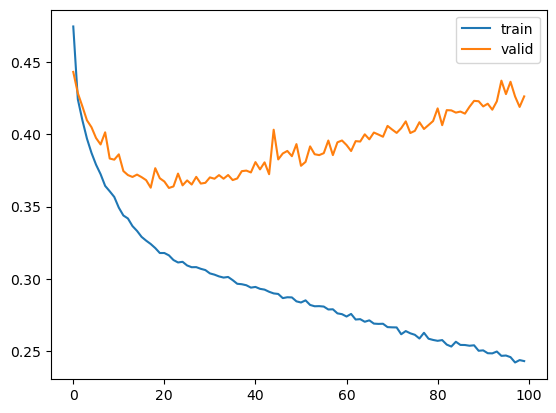

```python
# Capturing learning history per epoch
hist  = pd.DataFrame(history.history)
hist['epoch'] = history.epoch

# Plotting accuracy at different epochs
plt.plot(hist['loss'])
plt.plot(hist['val_loss'])
plt.legend(("train" , "valid") , loc =0)

## Complete the code to evaluate the model on X_test and y_test
_, results_train = model1.evaluate(X_train, y_train)
_, results_val = model1.evaluate(X_val, y_val)
_, results_test = model1.evaluate(X_test, y_test)
```

```python
print('Train accuracy: %.3f %%' % (results_train * 100))
print('Validation accuracy: %.3f %%' % (results_val * 100))
print('Test accuracy:\t%.3f %%' % (results_test * 100))
```

```
Train accuracy: 90.219 %
Validation accuracy: 83.688 %
Test accuracy:	84.850 %
```

**Confusion matrix**

```
Accuracy=0.837
Precision=0.644
Recall=0.445
F1 Score=0.526
```

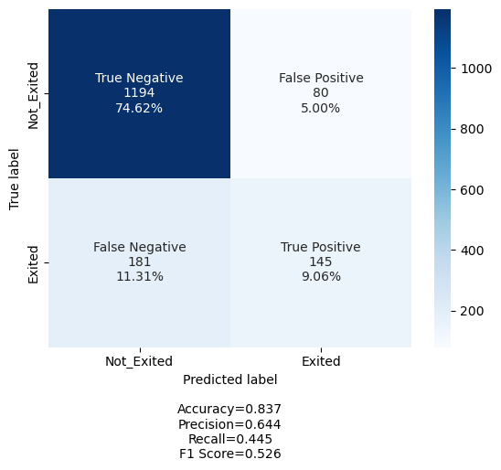

```python
## Complete the code to obtain the prediction on X_val and obtain the confusion matrix
y_pred1=model1.predict(X_val)

#Let's predict using default threshold
y_pred1 = (y_pred1 > 0.5)
cm2=confusion_matrix(y_val, y_pred1)
labels = ['True Negative','False Positive','False Negative','True Positive']
categories = [ 'Not_Exited','Exited']
model1_score = make_confusion_matrix(cm2,
                      group_names=labels,
                      categories=categories,
                      cmap='Blues')
```

```python
print(model1_score)
```

```
Accuracy=0.837
Precision=0.644
Recall=0.445
F1 Score=0.526
```

#### Observations:

- **Accuracy:** The accuracy of the model is 83.7%. This metric measures the proportion of correctly classified instances among all instances in the dataset.
- **Precision:** The precision of the model is 64.4%. Precision is the ratio of true positive predictions to the total positive predictions. It measures the accuracy of positive predictions made by the model.
- **Recall:** The recall of the model is 44.5%. Recall, also known as sensitivity or true positive rate, is the ratio of true positive predictions to the total actual positives. It measures the model's ability to identify positive instances correctly.
- **F1 Score:** The F1 score is 52.6%. The F1 score is the harmonic mean of precision and recall. It provides a balance between precision and recall, taking both false positives and false negatives into account.

### 2. Model Building: Neural Network model with Adam Optimizer (Early Stopping)

- **Hidden layers:** 1
- **Number of neurons in input layer 1:** 64
- **Input layer activation function:** ReLu Activation
- **Number of neurons in hidden layer 1:** 32
- **Hidden layer activation function:** ReLu Activation
- **Final activation function :** Sigmoid Activation
- **Optimizer:** ADAM
- **Loss:** Binary Cross-entropy
- **Epochs:** 500
- **Early stopping:** On validation loss

```python
backend.clear_session()
#Fixing the seed for random number generators so that we can ensure we receive the same output everytime
np.random.seed(2)
random.seed(2)
tf.random.set_seed(2)
```

```python
def create_model():
      ## Initializing the neural network
      model = Sequential()

      ##Complete the code to add the input layer with 64 neurons and relu as activation function
      model.add(Dense(64,activation='relu',input_dim = X_train.shape[1]))

      ## Complete the code to add the first hidden layer with 32 neurons with relu as activation functions
      model.add(Dense(32,activation='relu'))

      ## Complete the code to add the output layer with Sigmoid Activation
      model.add(Dense(1, activation = 'sigmoid'))

      ## Complete the code to initialize the model with Adam Optimer
      optimizer = tf.keras.optimizers.Adam(0.001)

      ## Complete the code to compile the model with binary cross entropy as loss function and accuracy as metrics
      model.compile(loss='binary_crossentropy',optimizer=optimizer,metrics=['accuracy'])
      return model
```

```python
model2=create_model()
model2.summary()
```

```
WARNING:absl:At this time, the v2.11+ optimizer `tf.keras.optimizers.Adam` runs slowly on M1/M2 Macs, please use the legacy Keras optimizer instead, located at `tf.keras.optimizers.legacy.Adam`.
WARNING:absl:There is a known slowdown when using v2.11+ Keras optimizers on M1/M2 Macs. Falling back to the legacy Keras optimizer, i.e., `tf.keras.optimizers.legacy.Adam`.
```

```
Model: "sequential"
_________________________________________________________________
 Layer (type)                Output Shape              Param #
=================================================================
 dense (Dense)               (None, 64)                704

 dense_1 (Dense)             (None, 32)                2080

 dense_2 (Dense)             (None, 1)                 33

=================================================================
Total params: 2,817
Trainable params: 2,817
Non-trainable params: 0
_________________________________________________________________
```

```python
history = model2.fit(X_train, y_train,batch_size=32,validation_data=(X_val,y_val),epochs=100,verbose=1)
```

**Loss function**

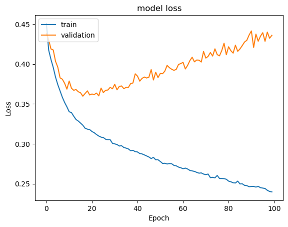

```python
#Plotting Train Loss vs Validation Loss
plt.plot(history.history['loss'])
plt.plot(history.history['val_loss'])
plt.title('model loss')
plt.ylabel('Loss')
plt.xlabel('Epoch')
plt.legend(['train', 'validation'], loc='upper left')
plt.show()
```

As you can see from the above image, this model is severely overfitting. Deep learning models are very sensitive to overfitting due to a large number of parameters. We need to find the optimal point where the training should be stopped.

The best solution for the above problem is **Early stopping**.

**Early stopping:**

During training, the model is evaluated on a holdout validation dataset after each epoch. If the performance of the model on the validation dataset starts to degrade or no improvement (e.g. loss begins to increase or accuracy begins to decrease), then the training process is stopped after certain iterations. The model at the time that training is stopped is then used and is known to have good generalization performance.

This procedure is called “early stopping” and is perhaps one of the oldest and most widely used forms of neural network regularization.

```python
#Importing classback API
# Defining Early stopping
earlyStopping = callbacks.EarlyStopping(monitor='val_loss', min_delta=0.001, patience=5)

## Complete the code to call the create_model() function
model2_e=create_model()

## Complete the code to train the model on X_train and y_train for 100 epochs and also use X_val and y_val as validation_data
history2_e = model2_e.fit(X_train, y_train,batch_size=32,epochs=500,verbose=1,validation_data=(X_val,y_val),callbacks=[earlyStopping])
```

```
WARNING:absl:At this time, the v2.11+ optimizer `tf.keras.optimizers.Adam` runs slowly on M1/M2 Macs, please use the legacy Keras optimizer instead, located at `tf.keras.optimizers.legacy.Adam`.
WARNING:absl:There is a known slowdown when using v2.11+ Keras optimizers on M1/M2 Macs. Falling back to the legacy Keras optimizer, i.e., `tf.keras.optimizers.legacy.Adam`.
```

**Loss function**

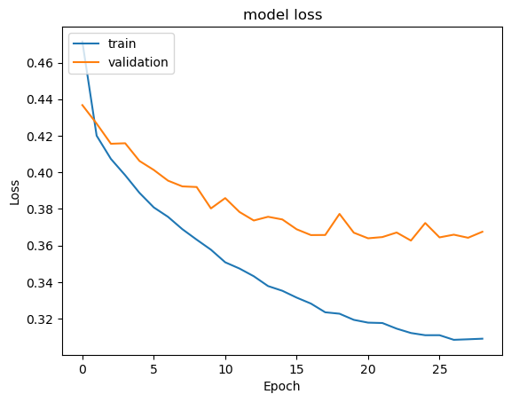

```python
# Plotting Train Loss vs Validation Loss
plt.plot(history2_e.history['loss'])
plt.plot(history2_e.history['val_loss'])
plt.title('model loss')
plt.ylabel('Loss')
plt.xlabel('Epoch')
plt.legend(['train', 'validation'], loc='upper left')
plt.show()
```

**Let's tune the threshold using ROC-AUC**

There are many ways we could locate the threshold with the optimal balance between false positive and true positive rates.

Firstly, the true positive rate is called the Sensitivity. The inverse of the false-positive rate is called the Specificity.

Sensitivity = TruePositive / (TruePositive + FalseNegative)

Specificity = TrueNegative / (FalsePositive + TrueNegative)

Where:

Sensitivity = True Positive Rate

Specificity = 1 – False Positive Rate

The Geometric Mean or G-Mean is a metric for imbalanced classification that, if optimized, will seek a balance between the sensitivity and the specificity.

G-Mean = sqrt(Sensitivity * Specificity)

```
Best Threshold=0.247348, G-Mean=0.808
```

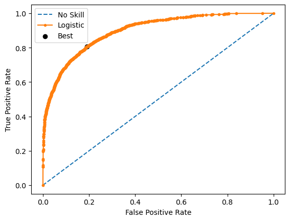

```python
# predict probabilities
yhat = model2_e.predict(X_train)
# keep probabilities for the positive outcome only
yhat = yhat[:, 0]
# calculate roc curves
fpr, tpr, thresholds = roc_curve(y_train, yhat)
# calculate the g-mean for each threshold
gmeans = np.sqrt(tpr * (1-fpr))
# locate the index of the largest g-mean
ix = np.argmax(gmeans)
print('Best Threshold=%f, G-Mean=%.3f' % (thresholds[ix], gmeans[ix]))
# plot the roc curve for the model
pyplot.plot([0,1], [0,1], linestyle='--', label='No Skill')
pyplot.plot(fpr, tpr, marker='.', label='Logistic')
pyplot.scatter(fpr[ix], tpr[ix], marker='o', color='black', label='Best')
# axis labels
pyplot.xlabel('False Positive Rate')
pyplot.ylabel('True Positive Rate')
pyplot.legend()
# show the plot
pyplot.show()
```

**Predict the results using the best threshold**

```python
#Predicting the results using best as a threshold
y_pred_e=model2_e.predict(X_val)
y_pred_e = (y_pred_e > thresholds[ix])
y_pred_e
```

```
array([[False],
       [False],
       [False],
       ...,
       [False],
       [ True],
       [ True]])
```

**Classification report**

```python
## Complete the code to obtain the classification report Hint: use y_val
cr=metrics.classification_report(y_val,y_pred_e)
print(cr)
```

```
              precision    recall  f1-score   support

           0       0.92      0.80      0.85      1274
           1       0.48      0.73      0.58       326

    accuracy                           0.78      1600
   macro avg       0.70      0.76      0.71      1600
weighted avg       0.83      0.78      0.80      1600
```

**Confusion matrix**

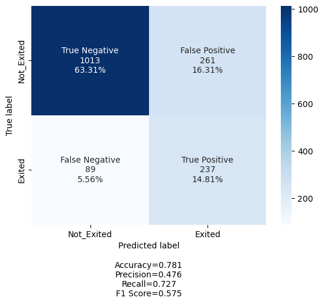

```python
## Complete the code with y_val and y_pred_e to plot the confusion matrix

cm1=confusion_matrix(y_val, y_pred_e)
labels = ['True Negative','False Positive','False Negative','True Positive']
categories = [ 'Not_Exited','Exited']
model2_score = make_confusion_matrix(cm1,
                      group_names=labels,
                      categories=categories,
                      cmap='Blues')
```

```python
print(model2_score)
```

```
Accuracy=0.781
Precision=0.476
Recall=0.727
F1 Score=0.575
```

#### Observations:

- **Accuracy:** The accuracy of the model is 78.1%. This metric measures the proportion of correctly classified instances among all instances in the dataset.
- **Precision:** The precision of the model is 47.6%. Precision is the ratio of true positive predictions to the total positive predictions. It measures the accuracy of positive predictions made by the model.
- **Recall:** The recall of the model is 72.7%. Recall, also known as sensitivity or true positive rate, is the ratio of true positive predictions to the total actual positives. It measures the model's ability to identify positive instances correctly.
- **F1 Score:** The F1 score is 57.5%. The F1 score is the harmonic mean of precision and recall. It provides a balance between precision and recall, taking both false positives and false negatives into account.

### 3. Model Improvement: Neural Network model (with Dropout)

```python
#Initializing the neural network
model_3 = Sequential()

#Adding the input layer with 64 neurons and relu as activation function
model_3.add(Dense(64,activation='relu',input_dim = X_train.shape[1]))

# Adding the first hidden layer with 32 neurons with relu as activation functions with dropout_rate= 0.2
model_3.add(Dropout(rate = 0.2))
model_3.add(Dense(32,activation='relu'))

# # Adding the second hidden layer with 16 neurons with relu as activation functions with dropout_rate= 0.1
model_3.add(Dropout(rate = 0.1))
model_3.add(Dense(16,activation='relu'))

# Adding the output layer
model_3.add(Dense(1, activation = 'sigmoid'))
```

```python
# Summary of the model
model_3.summary()
```

```
Model: "sequential_2"
_________________________________________________________________
 Layer (type)                Output Shape              Param #
=================================================================
 dense_6 (Dense)             (None, 64)                704

 dropout (Dropout)           (None, 64)                0

 dense_7 (Dense)             (None, 32)                2080

 dropout_1 (Dropout)         (None, 32)                0

 dense_8 (Dense)             (None, 16)                528

 dense_9 (Dense)             (None, 1)                 17

=================================================================
Total params: 3,329
Trainable params: 3,329
Non-trainable params: 0
_________________________________________________________________
```

```python
# Initialize the ANN with Adam optimizer
optimizer = tf.keras.optimizers.Adam(0.001)

# Complete the code to compile the model with binary cross entropy as loss function and accuracy as metrics
model_3.compile(loss='binary_crossentropy',optimizer=optimizer,metrics=['accuracy'])
```

```
WARNING:absl:At this time, the v2.11+ optimizer `tf.keras.optimizers.Adam` runs slowly on M1/M2 Macs, please use the legacy Keras optimizer instead, located at `tf.keras.optimizers.legacy.Adam`.
WARNING:absl:There is a known slowdown when using v2.11+ Keras optimizers on M1/M2 Macs. Falling back to the legacy Keras optimizer, i.e., `tf.keras.optimizers.legacy.Adam`.
```

```python
#Fitting the ANN with batch_size = 32 and 100 epochs
history_3 = model_3.fit(X_train,y_train,batch_size=32,epochs=100,verbose=1,validation_data=(X_val,y_val),callbacks=[earlyStopping])
```

**Loss function**

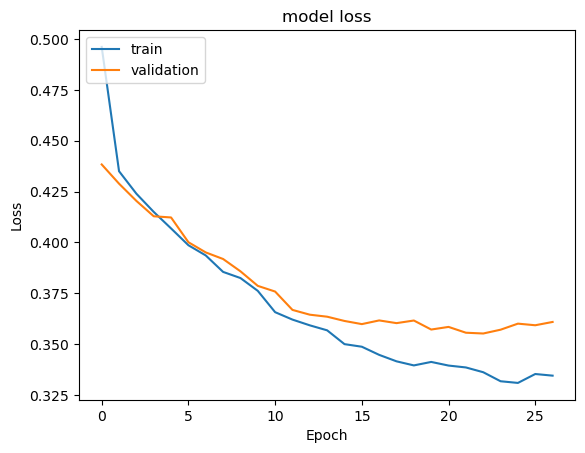

```python
# Complete the code to plot the Train Loss and Validation Loss
plt.plot(history_3.history['loss'])
plt.plot(history_3.history['val_loss'])
plt.title('model loss')
plt.ylabel('Loss')
plt.xlabel('Epoch')
plt.legend(['train', 'validation'], loc='upper left')
plt.show()
```

```
Best Threshold=0.173562, G-Mean=0.802
```

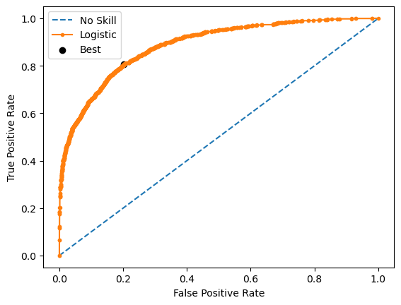

```python
# predict probabilities
yhat = model_3.predict(X_train)
# keep probabilities for the positive outcome only
yhat = yhat[:, 0]
# calculate roc curves
fpr, tpr, thresholds = roc_curve(y_train, yhat)
# calculate the g-mean for each threshold
gmeans = np.sqrt(tpr * (1-fpr))
# locate the index of the largest g-mean
ix = np.argmax(gmeans)
print('Best Threshold=%f, G-Mean=%.3f' % (thresholds[ix], gmeans[ix]))
# plot the roc curve for the model
pyplot.plot([0,1], [0,1], linestyle='--', label='No Skill')
pyplot.plot(fpr, tpr, marker='.', label='Logistic')
pyplot.scatter(fpr[ix], tpr[ix], marker='o', color='black', label='Best')
# axis labels
pyplot.xlabel('False Positive Rate')
pyplot.ylabel('True Positive Rate')
pyplot.legend()
# show the plot
pyplot.show()
```

**Predict the results using the best threshold**

```python
#Predicting the results using best as a threshold
y_pred_e=model_3.predict(X_val)
y_pred_3 = (y_pred_e > thresholds[ix])
y_pred_3
```

```
array([[ True],
       [False],
       [False],
       ...,
       [False],
       [ True],
       [ True]])
```

**Classification report**

```python
# Complete the code to obtain the classification report
cr=metrics.classification_report(y_val,y_pred_3)
print(cr)
```

```
              precision    recall  f1-score   support

           0       0.92      0.78      0.85      1274
           1       0.47      0.75      0.58       326

    accuracy                           0.78      1600
   macro avg       0.70      0.77      0.71      1600
weighted avg       0.83      0.78      0.79      1600
```

**Confusion report**

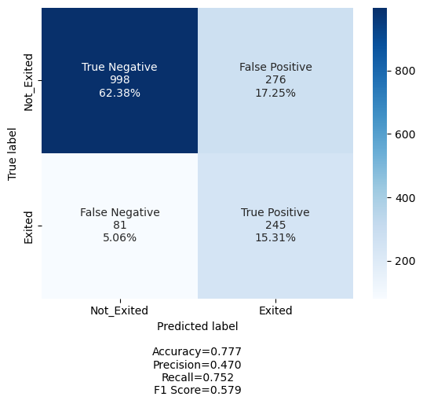

```python
# Complete the code to obtain the confusion matrix

cm1=confusion_matrix(y_val, y_pred_3)
labels = ['True Negative','False Positive','False Negative','True Positive']
categories = [ 'Not_Exited','Exited']
model3_score = make_confusion_matrix(cm1,
                      group_names=labels,
                      categories=categories,
                      cmap='Blues')
```

```python
print(model3_score)
```

```
Accuracy=0.777
Precision=0.470
Recall=0.752
F1 Score=0.579
```

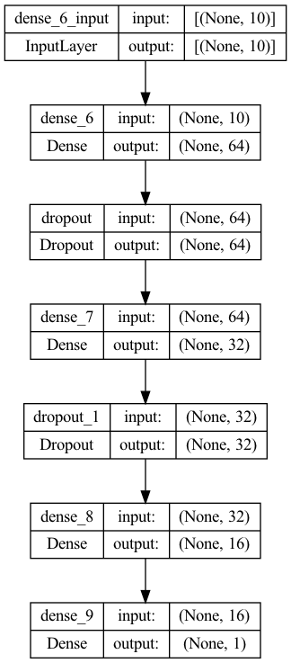

```python
# show network structure
keras.utils.plot_model(model_3, "networkModel.png", show_shapes=True)
```

#### Observations:

- **Accuracy:** The accuracy of the model is 77.7%. This metric measures the proportion of correctly classified instances among all instances in the dataset.
- **Precision:** The precision of the model is 47.0%. Precision is the ratio of true positive predictions to the total positive predictions. It measures the accuracy of positive predictions made by the model.
- **Recall:** The recall of the model is 75.2%. Recall, also known as sensitivity or true positive rate, is the ratio of true positive predictions to the total actual positives. It measures the model's ability to identify positive instances correctly.
- **F1 Score:** The F1 score is 57.9%. The F1 score is the harmonic mean of precision and recall. It provides a balance between precision and recall, taking both false positives and false negatives into account.

### 4. Model Improvement: Neural Network model ( with Hyperparameter tuning)

```python
backend.clear_session()
#Fixing the seed for random number generators so that we can ensure we receive the same output everytime
np.random.seed(2)
random.seed(2)
tf.random.set_seed(2)
```

```python
def create_model_v2(dropout_rate=0.1,lr=0.001,layer_1=64,layer_2=32):
    np.random.seed(1337)

    #Initializing the neural network
    model4 = Sequential()

    # Input layer (by specifying input dimension)
    model4.add(Dense(layer_1,activation='relu',input_dim = X_train.shape[1]))

    ## Adding dropout with dropout rate=0.5
    model4.add(Dropout(0.5))

    # # Adding the hidden layer
    model4.add(Dense(layer_2,activation='relu'))

    # # Adding the output layer
    model4.add(Dense(1, activation='sigmoid'))

    # Adding Adam initializer
    optimizer = tf.keras.optimizers.Adam(learning_rate=lr)

    model4.compile(optimizer = optimizer,loss = 'binary_crossentropy', metrics = ['accuracy'])
    return model4
```

**Using Grid search**

```python
keras_estimator = KerasClassifier(build_fn=create_model_v2, verbose=1)
```

```python
# define the grid search parameters
param_grid = {
    'batch_size':[40, 64, 128],
    "lr":[0.01,0.001,0.1]}


kfold_splits = 3
grid = GridSearchCV(estimator=keras_estimator,
                    verbose=1,
                    cv=kfold_splits,
                    param_grid=param_grid,n_jobs=-1)
```

```python
## Complete the code to fit the model on train data and use x_val and y_val as validation data
grid_result = grid.fit(X_train, y_train,validation_data = (X_val,y_val),verbose=1)

# Summarize results
print("Best: %f using %s" % (grid_result.best_score_, grid_result.best_params_))
# Printing mean
means = grid_result.cv_results_['mean_test_score']
# Printing standard deviation
stds = grid_result.cv_results_['std_test_score']
# Printing best parameters
params = grid_result.cv_results_['params']
```

```
Fitting 3 folds for each of 9 candidates, totalling 27 fits
```

[output not shown]

[output not shown]

[output not shown]

[output not shown]

```
WARNING:absl:At this time, the v2.11+ optimizer `tf.keras.optimizers.Adam` runs slowly on M1/M2 Macs, please use the legacy Keras optimizer instead, located at `tf.keras.optimizers.legacy.Adam`.
WARNING:absl:There is a known slowdown when using v2.11+ Keras optimizers on M1/M2 Macs. Falling back to the legacy Keras optimizer, i.e., `tf.keras.optimizers.legacy.Adam`.
```

```
Best: 0.803906 using {'batch_size': 128, 'lr': 0.01}
```

**Let's create the final model with the obtained configuration after hyperparameter tuning**

```python
# Creating the model
estimator_v2=create_model_v2(lr=grid_result.best_params_['lr'])
# Printing model summary
estimator_v2.summary()
```

```
WARNING:absl:At this time, the v2.11+ optimizer `tf.keras.optimizers.Adam` runs slowly on M1/M2 Macs, please use the legacy Keras optimizer instead, located at `tf.keras.optimizers.legacy.Adam`.
WARNING:absl:There is a known slowdown when using v2.11+ Keras optimizers on M1/M2 Macs. Falling back to the legacy Keras optimizer, i.e., `tf.keras.optimizers.legacy.Adam`.
```

```
Model: "sequential_1"
_________________________________________________________________
 Layer (type)                Output Shape              Param #
=================================================================
 dense_3 (Dense)             (None, 64)                704

 dropout_1 (Dropout)         (None, 64)                0

 dense_4 (Dense)             (None, 32)                2080

 dense_5 (Dense)             (None, 1)                 33

=================================================================
Total params: 2,817
Trainable params: 2,817
Non-trainable params: 0
_________________________________________________________________
```